# Lecture 11: CI Wrap-up, & Intro to Hypothesis Testing

## STAT 324

### Ralph Trane

### University of Wisconsin–Madison<br><br>

### Spring 2020

# Practicalities

* Midterm I on Tuesday 3/3 in class (4.00p-5.15p in Van Vleck B130)

* Notes are allowed

* Calculator recommended

* No connected devices!

* Practice problem set on Canvas

* Q/A Review tomorrow and Thursday

* No homework assigned this week

# Misc.

* Recap of `\(t\)`-distribution/introduction of t-table

* Comment on homework questions re: sample size.

# Recap of Confidence Intervals

1. Want to do better than just a single "best guess" (= point estimate)

2. Find a good estimator for parameter of interest
    * think `\(\bar{X}\)` for `\(\mu\)`, or `\(P\)` for `\(\pi\)`

3. Find distribution of some quantity involving estimator and parameter of interest
    * `\(\frac{\bar{X} - \mu}{s/\sqrt{n}} = \frac{\bar{X} - E(\bar{X})}{\widehat{\text{SD}}(\bar{X})}\)`

4. Find critical values in the distribution
    * i.e. cut-off `\(\alpha/2\)` on each side of distribution

# Recap of Confidence Intervals

The hard part: how do we find the distribution of quantity?

Often, how do we find the distribution of `\(\frac{\bar{X} - E(\bar{X})}{\widehat{\text{SD}}(\bar{X})}\)`?

A few tricks:

1. If `\(\bar{X} \sim N\)`, then `\(\frac{\bar{X} - E(\bar{X})}{\widehat{\text{SD}}(\bar{X})} \sim t_{n-1}\)`.

2. If `\(\bar{X}\)` not necessarily normal, then bootstrap.

Two things result in `\(\bar{X} \sim N\)`:

1. Data themselves are normal
    - i.e. `\(X_1,...,X_n \sim N\)`

2. `\(n > 30\)`, because then CLT

# Recap of Confidence Intervals

Once we get an interval, how do we interpret it?

* The standard phrase: "We are `\((1-\alpha)\cdot 100\%\)` confident the interval contains the true value"

* Confident = repeating the process many times will cover the truth `\((1-\alpha)\cdot 100\%\)` of the time

* The CI is a range of values we find plausible to be the truth given the data (at a certain level of confidence)

Sometimes we have that one thing we are really interested in: "does it seem likely that the true mean is 5?"

First step in answering this question: write down your *statistical hypotheses*. These always come in pairs:

* the *null* hypothesis is the simplest (and often uninteresting) hypothesis
    * we take this to be "status quo" - we are trying to dismiss this

* the *alternative* hypothesis is what we will test against
    * this is what we will adopt, if we dismiss "status quo"

Example: "is the true mean 5?" would dictate the null hypothesis `\(H_0: \mu = 5\)`. We now have a choice for the alternative:

* `\(H_A: \mu > 5\)`
* `\(H_A: \mu < 5\)`
* `\(H_A: \mu \neq 5\)`

For now, focus on the first one.

Want to test `\(H_0: \mu = 5\)` vs. `\(H_A: \mu > 5\)`.

Gather data, estimate `\(\mu\)`.

```r
head(samp,n = 5)
```

```
## # A tibble: 5 x 1
##       x
##   <dbl>
## 1  3.36
## 2  5.05
## 3  5.83
## 4  7.23
## 5  5.17
```

We get `\(\bar{x}_{\text{obs}} = 6.468\)`.

Conclusion: since `\(\bar{x}_{\text{obs}} > 5\)`, surely `\(\mu > 5\)`?

Of course not! We never expect `\(\bar{X}\)` to be **exactly** the true mean, simply "close to it".

Remember, `\(H_0: \mu = 5\)` is status quo. So the question is, is `\(\bar{x}_{\text{obs}}\)` far enough from `\(5\)` that we no longer think `\(\mu = 5\)`?

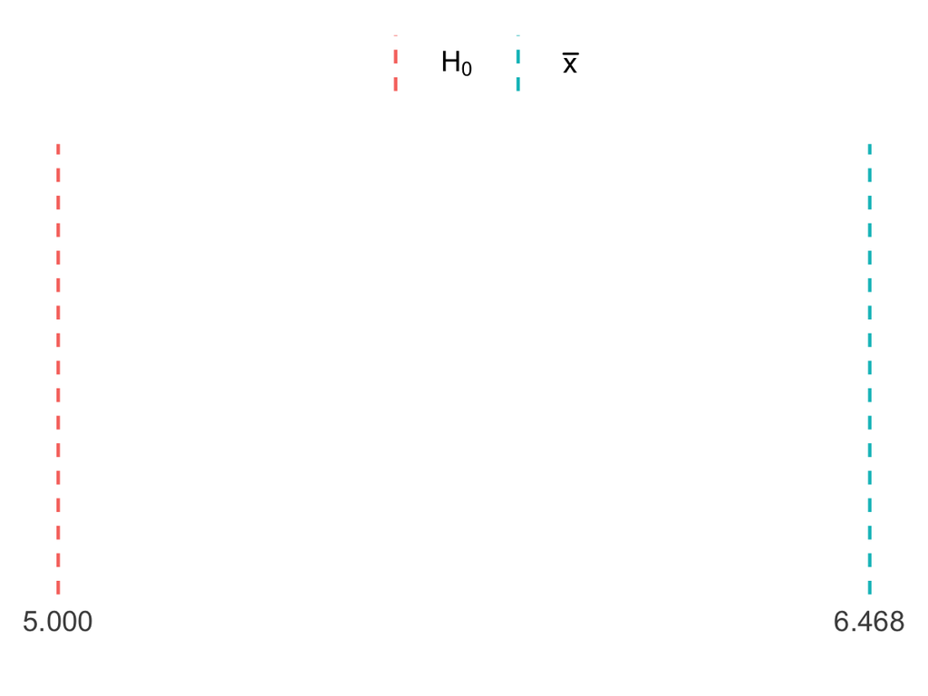

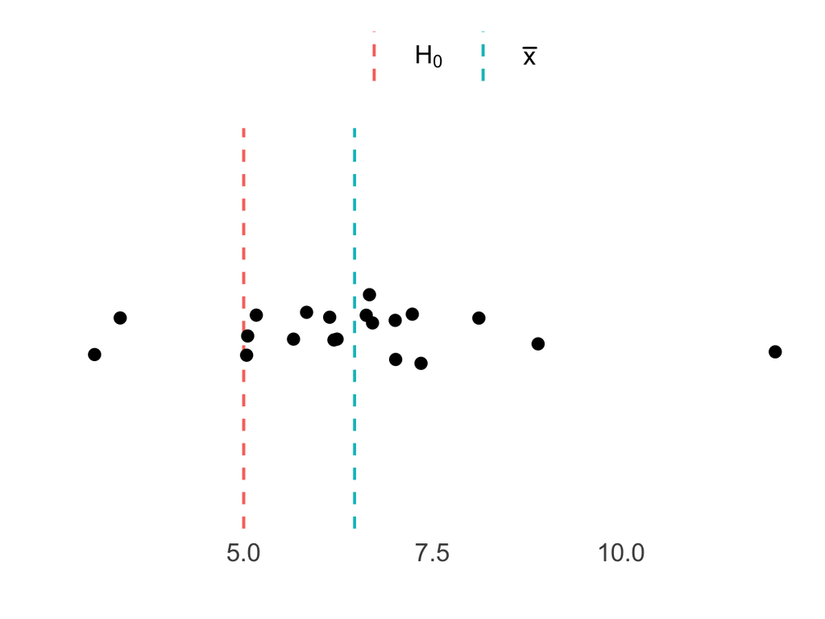

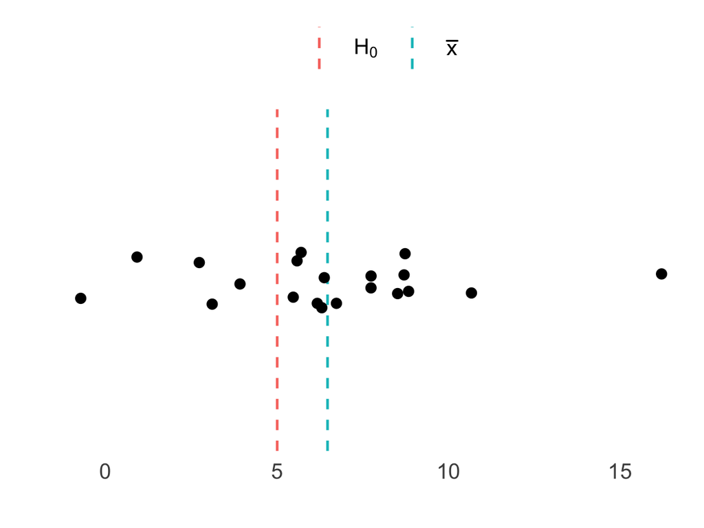

Where do we draw the line?

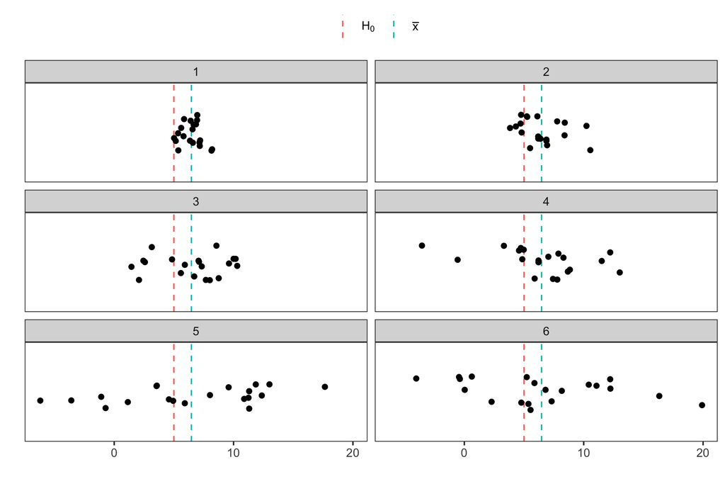

Where do we draw the line? Kind of comparing difference to variation.

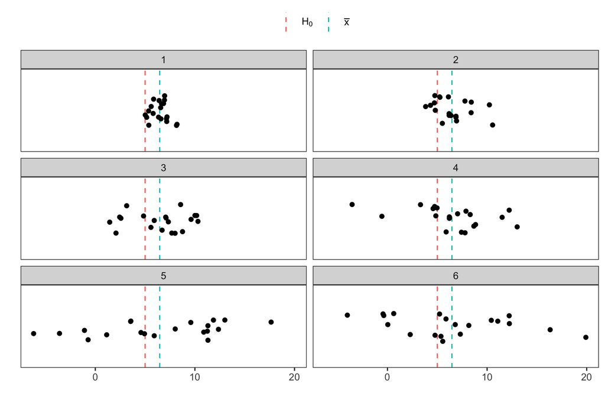

Comparing `\(\bar{X} - \mu\)` to a measure of variation. Which of the following provide most evidence against the null `\(H_0: \mu = 5\)`?

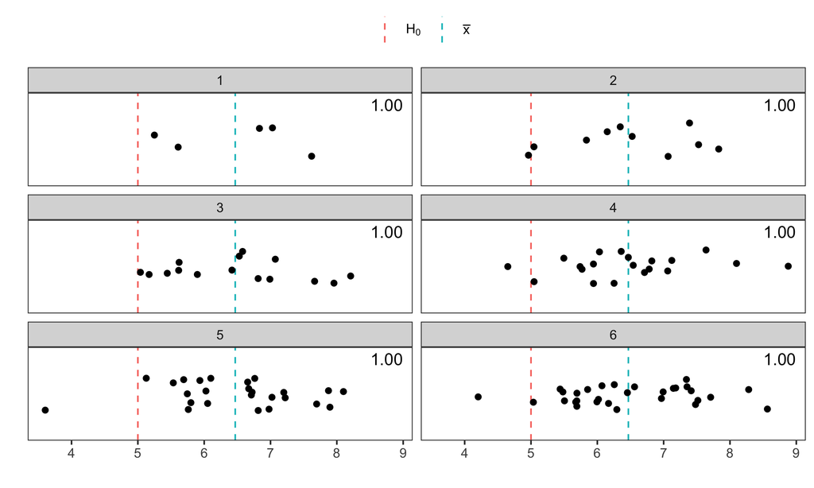

Would like our measure to have some dependency on `\(n\)`.

What if we use `\(\frac{\bar{X} - \mu}{\widehat{\text{SD}}(\bar{X})}\)`?

* measures deviation from hypothesized mean relative to measure of variation

* if difference `\(\bar{X} - \mu\)` is large, this quantity is large

* since `\(\widehat{\text{SD}}(\bar{X}) = s/\sqrt{n}\)`, larger `\(n\)` implies larger value

Intuitively, smart choice!

But when is this "large enough" that we would throw out `\(H_0: \mu = 5\)`?

Let's pretend that `\(\mu=5\)`. I.e. pretend `\(E(X_i) = 5\)`. Then `\(E(\bar{X}) =\)`

`\(5\)`.

Let's pretend `\(\bar{X} \sim N\)`. (Does this seem outrageous?

No, because CLT!)

So, `\(T = \frac{\bar{X} - 5}{\widehat{\text{SD}}(\bar{X})} \sim t_{n-1}\)`.

This is great! We can now say something about " is the observed `\(\bar{x}_{\text{obs}}\)` far from `\(5\)`?", **IF** `\(H_0: \mu = 5\)` is true!

If `\(\bar{x}_{\text{obs}}\)` is close to `\(5\)`, then `\(T_{\text{obs}}\)` is close to `\(0\)`. (Here `\(T_{\text{obs}}\)` is the observed value of `\(T\)`.)

**IF** `\(H_0: \mu = 5\)`, we can find `\(P\left(T > T_{\text{obs}}\right)\)`.

In other words, **IF** `\(H_0: \mu = 5\)`, we can find *the probability of seeing something "more absurd"/"more extreme"/"further away"* than what we observe.

If this probability is small, our `\(\bar{x}_{\text{obs}}\)` is deemed "far from" the hypothesized mean of `\(5\)`, hence the sample seems to suggest that `\(\mu = 5\)` is not the correct value.

So, we have taken the question "is 6.468 far from `\(5\)`?", which is highly subjective, and reformulated it as "is the probability of observing something "more extreme" large?", which is...

still highly subjective, **BUT** now on a scale we all know and love!

This new question is unitless - it is a probability between 0 and 1.

You might think `\(0.1\)` is small, while I would use `\(0.01\)` as a cut-off for "small", but at least we are now operating on the same scale AND we can relate to the choice of others.

So, is 6.468 far from `\(5\)`? Find `\(T_{\text{obs}} = \frac{\bar{x}_{\text{obs}} - 5}{s/\sqrt{20}} = 3.415\)` and see if it is far from `\(0\)`:

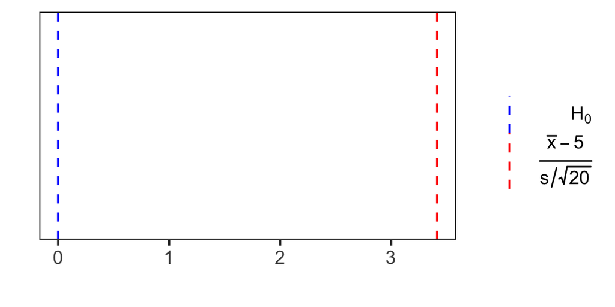

So, is 6.468 far from `\(5\)`? Find `\(T_{\text{obs}} = \frac{\bar{x}_{\text{obs}} - 5}{s/\sqrt{20}} = 3.415\)` and see if it is far from `\(0\)`, when compared to the `\(t_{n-1}\)`-distribution:

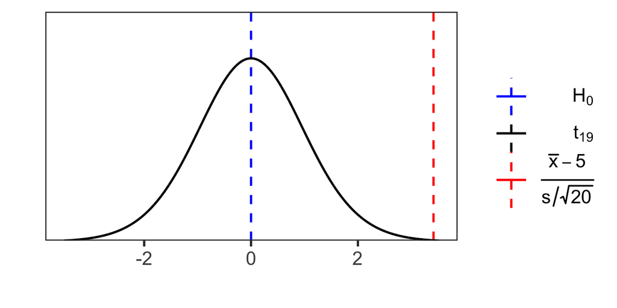

The most general strategy:

1. Set up null and alternative hypotheses:
    - `\(H_0: \mu = \mu_0\)` vs.
        - `\(H_A: \mu > \mu_0\)` or `\(H_A: \mu < \mu_0\)` or `\(H_A: \mu \neq \mu_0\)`
2. Pick cut-off for "small probability"
    - called *significance level* and is denoted by `\(\alpha\)`
    - often `\(0.05\)`, `\(0.01\)`, or `\(0.001\)`
2. Find good good *test statistic*
    - example: when wondering about true mean, `\(T = \frac{\bar{X} - \mu_0}{s/\sqrt{n}}\)`
3. Find distribution *assuming `\(H_0\)` is true!*
    - if `\(H_0: \mu = \mu_0\)` is true, then `\(T \sim t_{n-1}\)`
4. Find the *p-value*: probability of being "more extreme"
    - if `\(H_A: \mu > \mu_0\)`, "more extreme" = even larger, so find `\(P(T > T_{\text{obs}})\)`
    - if `\(H_A: \mu < \mu_0\)`, "more extreme" = even smaller, so find `\(P(T < T_{\text{obs}})\)`
    - if `\(H_A: \mu \neq \mu_0\)`, "more extreme" = even further away from zero, so find `\(P(T > |T_{\text{obs}}|) + P(T < -|T_{\text{obs}}|)\)`

Performing a hypothesis test results in one of two thing:

1. lots of evidence against the null (i.e. `\(\bar{x}_{\text{obs}}\)` is far from `\(\mu\)` above) leads us to *reject* `\(H_0\)`

2. less evidence against the null (i.e. `\(\bar{x}_{\text{obs}}\)` is close to `\(\mu\)` above) leads us to *not reject* `\(H_0\)`

Note:

* we **NEVER** accept the null, we **NEVER** accept the alternative.

* we **NEVER** find the truth, we simply reject suggestions.

We will never know the truth, so mistakes happen:

1. If we reject the null, but the null is actually true, we make a **type I** error.

2. If we do not reject the null, but the null is actually false, we make a **type II** error.

| Result\Truth | H<sub>0</sub> true | H<sub>0</sub> false |
| --- | --- | --- |
| Reject | Type I | No mistake |
| Do not reject | No mistake | Type II |

Since we never know the truth, we cannot check if a mistake occurred, but we can control the probability it occurs.

We use

`$$P(\text{type I error}) = P(\text{reject } H_0 | H_0 \text{ true}) = \alpha$$`

and

`$$P(\text{type II error}) = P(\text{do not reject } H_0 | H_0 \text{ false}) = \beta$$`

Generally, we want `\(\alpha\)` and `\(\beta\)` to be

small.

Closely related to `\(\beta\)` is the idea of *statistical power*: the probability that we reject `\(H_0\)` when `\(H_0\)` is indeed false! I.e.

$$
\text{Power} = P(\text{reject } H_0 | H_0 \text{ false}) = 1 - P(\text{do not reject } H_0 | H_0 \text{ false}) = 1 - \beta.
$$

So, we want power to be

large.

Unfortunately, (for fixed sample size `\(n\)`) decreasing `\(\alpha\)` increases `\(\beta\)`, and vice versa! So a trade-off to be made - do you want lower probability of Type I error, or lower probability of type II error.

Three more concepts that are closely related: *significance level*, *p-value*, and *rejection region*.

* The *significance level* is your cut-off for what constitutes a small probability.

* The *p-value* is the probability of observing something more extreme **IF** the null hypothesis is true
    - p-value `\(= P(\text{more extreme}|H_0 \text{ true})\)`.
    - what it means to be "more extreme" is determined by `\(H_A\)`

* The *rejection region* (RR) is all the values that would result in a p-value smaller than the significance level
    - the opposite of the rejection region is called the *acceptance region*

Consider `\(H_0: \mu = 5\)` vs. `\(H_A: \mu > 5\)`.

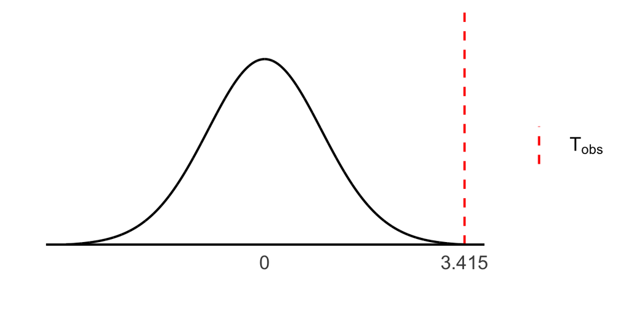

Consider `\(H_0: \mu = 5\)` vs. `\(H_A: \mu > 5\)`.

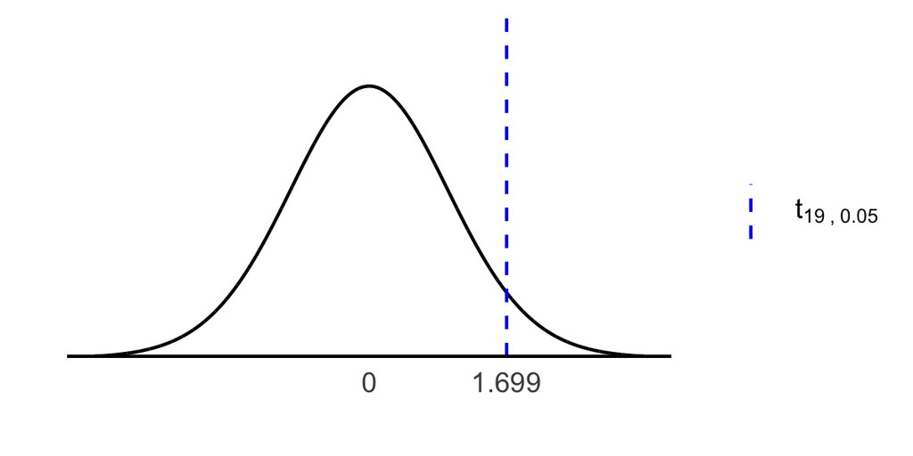

I.e. we would reject if test statistic is greater than 1.699. So the rejection region on the test statistic scale is `\([1.699, \infty)\)`.

This is not super useful in the sense that we do not have a good understanding of what a test statistic of, say, `\(3\)` is.

Fortunately, we can do even better! We can translate this back onto the `\(\bar{X}\)` scale.

So,

* reject when `\(\text{p-value} < \alpha\)`

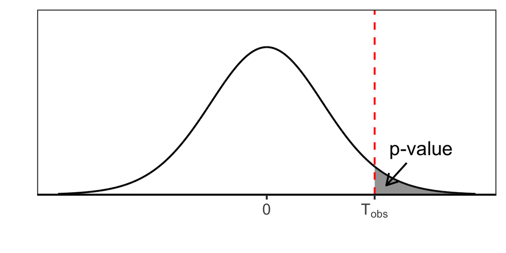

So,

* reject when `\(\text{p-value} < \alpha\)`

* happens when `\(\frac{\bar{x}_{\text{obs}} - 5}{\widehat{\text{SD}}(\bar{X})} = T_{\text{obs}} > t_{19, \alpha} = 1.699\)`
    * so RR for test statistic = `\([1.699, \infty)\)`

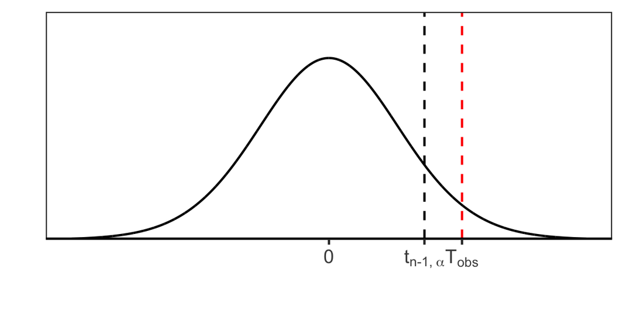

So,

* reject when `\(\text{p-value} < \alpha\)`

* happens when `\(\frac{\bar{x}_{\text{obs}} - 5}{\widehat{\text{SD}}(\bar{X})} = T_{\text{obs}} > t_{n-1, \alpha} = 1.699\)`
    * so RR for test statistic = `\([1.699, \infty)\)`